# 에이전트의 제어실

자동화가 강해질수록 인간의 관측이 더 중요해지는 이유 — 제어공학 × 조직론 × 인지과학

저자

Insight Lab × Chimera AI

공개

2026년 8월 16일

**노트핵심 문장**

AI 에이전트의 위험은 자율성 그 자체보다 **조직이 결과를 관측하는 속도보다 에이전트가 행동하는 속도가 빨라지는 것**에서 시작된다. 인간을 루프에 넣는 것만으로는 충분하지 않다. 인간이 무엇을 보고, 언제 멈추고, 어떤 권한으로 되돌릴 수 있는지가 설계되어야 한다.

# 1 자동화는 왜 제어 문제가 되는가

한 사람이 하루에 열 건의 보고서를 만들 때는 실수를 눈으로 찾을 수 있다. 에이전트가 같은 시간에 천 건을 만들면 조직은 더 생산적이 된 것처럼 보인다. 그러나 결과를 검토하는 능력이 열 배만 늘었다면, 조직은 생산량이 아니라 **미관측 영역**을 구입한 셈이다.

제어공학에서 시스템을 안정시키려면 세 가지가 필요하다. 현재 상태를 보는 센서, 목표와 실제의 차이를 계산하는 피드백, 그리고 시스템을 바꾸는 조작기다. 조직에 대응시키면 로그·평가셋이 센서이고, 품질 기준이 기준값이며, 승인·중단·롤백 권한이 조작기다. “사람이 최종 확인한다”는 문장은 이 셋 중 어느 것도 구체화하지 않는다.

자동화 편향 연구는 인간이 자동 추천을 과신하거나 잘못 적용할 수 있음을 보여준다. 최근 체계적 문헌검토는 설명 가능한 AI도 편향을 줄이기도, 오히려 과신을 키우기도 한다고 정리한다. [AI & Society 문헌검토](https://link.springer.com/article/10.1007/s00146-025-02422-7) 확장형 감독에 관한 2026년 실험은 온라인 조사를 시켜도 틀린 시스템 답에 대한 평가자의 확신이 커질 수 있음을 보고했다. [AAAI 2026](https://ojs.aaai.org/index.php/AAAI/article/view/41124)

# 2 열린 루프와 닫힌 루프

아래 모의실험은 실제 기업 데이터가 아니다. 하루 200개 작업, 에이전트 기본 오류율 8%, 인간 검토율과 탐지율을 가정해 **구조가 만드는 방향**만 비교한다.

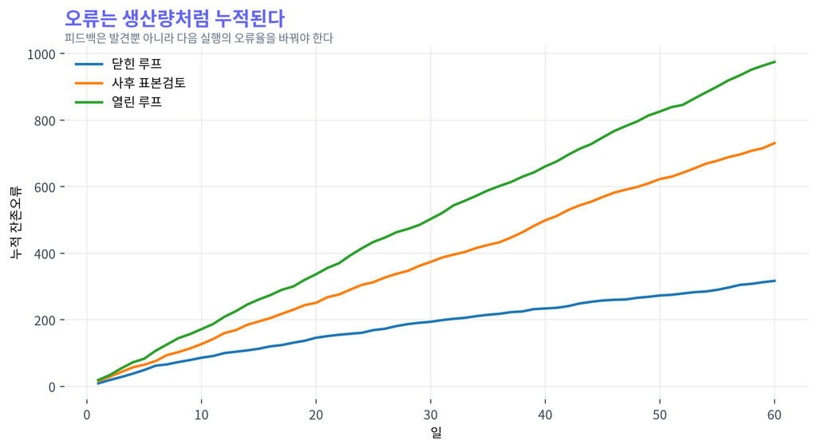

그림 1: 그림 1. 동일한 에이전트 오류율에서 검토·수정 피드백 유무에 따른 누적 잔존오류. 모의실험이며 실제 조직의 예측치가 아니다.

닫힌 루프의 핵심은 검토량이 많다는 데 있지 않다. 검토 결과가 프롬프트, 도구 권한, 평가 규칙, 검색 범위로 되돌아간다는 데 있다. 오류를 고치되 시스템을 바꾸지 않으면 품질팀은 영원히 같은 결함을 닦는 청소부가 된다.

# 3 검토율보다 중요한 것: 독립성

인간 검토자가 에이전트의 설명을 그대로 읽고 같은 자료만 검색하면 둘의 오류는 독립적이지 않다. 두 명이 확인해도 하나의 판단을 두 번 반복할 수 있다. 센서가 고장 난 계기판을 다시 읽는다고 비행기가 안전해지지 않는 것과 같다.

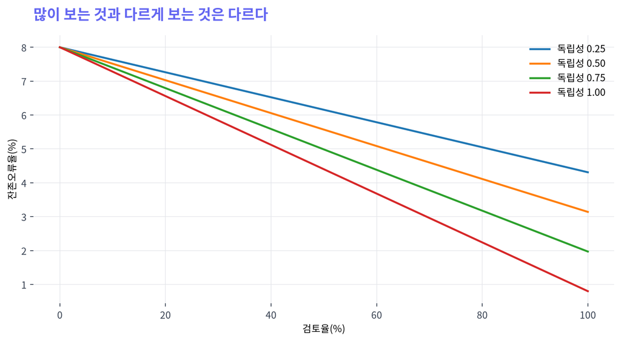

그림 2: 그림 2. 검토율·탐지율·판단독립성에 따른 잔존오류율. 독립성이 낮으면 검토량 증가의 효과가 급격히 줄어든다.

독립성을 만드는 운영 규칙은 구체적이다.

1. 생성 에이전트가 보지 않은 원자료로 검증한다.
2. 정답을 설명하게 하기 전에 반증 조건을 먼저 쓴다.
3. 같은 모델의 두 번째 호출을 독립 검토자로 세지 않는다.
4. 결과 샘플링을 에이전트가 고르지 못하게 한다.
5. 실패 사례도 성공 사례와 같은 기간 보존한다.

# 4 지연과 이득: 빨리 고치려다 흔들리는 조직

피드백은 강할수록 좋은 것이 아니다. 판매 예측이 빗나갈 때마다 재고를 크게 조정하면 공급망이 진동하듯, 에이전트 규칙을 오류 한 건마다 크게 바꾸면 어제의 결함을 고친 규칙이 오늘의 정상 사례를 망가뜨릴 수 있다. 특히 평가 결과가 며칠 늦게 들어오면 조직은 이미 사라진 상태를 향해 조향한다.

간단한 지연 제어식으로 이를 표현할 수 있다.

$$e_{t+1}=e_t-g e_{t-d}+w_t$$

$e_t$는 목표 품질과의 오차, $g$는 교정 강도, $d$는 검증 지연, $w_t$는 새로운 업무·데이터에서 들어오는 충격이다.

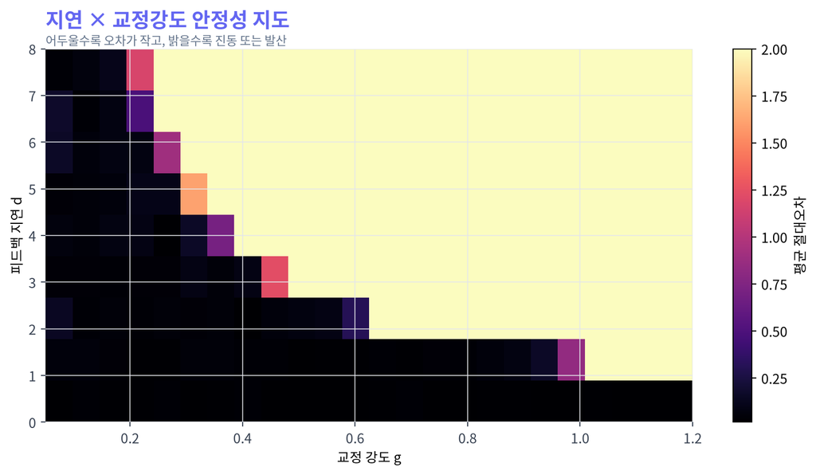

그림 3: 그림 3. 피드백 지연과 교정 강도에 따른 80단계 후 평균 절대오차. 밝은 영역은 진동·불안정 위험이 크다.

이 그림의 통찰은 “천천히 하라”가 아니다. **지연이 길면 한 번의 수정 폭을 줄이고, 빠른 센서를 먼저 만들어야 한다**는 것이다. 월말 품질회의만 있는 조직은 실시간으로 행동하는 에이전트에 큰 권한을 주면 안 된다.

# 5 처리량과 품질의 효율경계

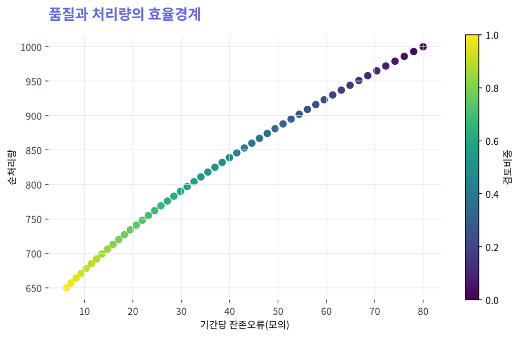

그림 4: 그림 4. 검토비중에 따른 순처리량과 잔존오류의 모의 효율경계. 전수검토가 항상 최적은 아니며 위험도에 따른 계층화가 필요하다.

전수검토는 자동화의 처리량 이점을 없앨 수 있고, 무검토는 오류를 축적한다. 답은 평균 검토율 하나가 아니라 **위험에 따른 다른 루프**다.

- 낮은 위험: 자동 실행 + 무작위 표본감사
- 중간 위험: 실행 전 규칙검사 + 사후 표본검토
- 높은 위험: 인간 승인 + 독립 원자료 검증
- 되돌릴 수 없는 행위: 이중 승인 + 실행 제한 + 롤백 사전연습

# 6 조직도보다 중요한 권한도

에이전트 조직도를 그리면 오케스트레이터, 조사 에이전트, 코딩 에이전트, 검수 에이전트가 깔끔하게 배열된다. 그러나 누가 멈출 수 있는지 표시하지 않으면 그것은 조직도가 아니라 배선도다.

운영문서에는 최소한 다음이 있어야 한다.

| 항목 | 질문 |
| --- | --- |
| 상태변수 | 지금 품질을 무엇으로 측정하는가 |
| 기준값 | 허용 오류와 금지 오류는 무엇인가 |
| 센서 | 어떤 로그·샘플·평가셋이 상태를 보여주는가 |
| 지연 | 오류가 발생한 뒤 발견까지 얼마나 걸리는가 |
| 조작기 | 프롬프트·도구·권한·배포 중 무엇을 바꿀 수 있는가 |
| 차단기 | 누가 어떤 조건에서 실행을 멈추는가 |
| 복구 | 잘못된 행동을 어떻게 되돌리는가 |

여기서 `PLAN.md`는 목표와 검증 순서를 정하고, `SKILL.md`는 반복 가능한 조작 규칙을 담으며, 실행 로그는 센서 역할을 한다. 문서가 많아서 안전한 것이 아니라 세 문서가 실제 피드백 루프를 닫을 때 안전하다.

# 7 반론: 너무 많은 제어가 혁신을 죽이지 않는가

그럴 수 있다. 낮은 위험의 탐색까지 승인 절차로 묶으면 조직은 에이전트보다 느려지고 사람은 형식적 클릭만 하게 된다. 이것도 자동화 편향의 다른 얼굴이다. 책임이 있다는 느낌을 주지만 실제 판단은 사라진다.

따라서 제어는 모든 행동에 같은 마찰을 주는 브레이크가 아니다. 고속도로의 차선, 속도제한, 충돌방지장치처럼 **속도를 허용하기 위한 경계조건**이어야 한다. 되돌릴 수 있는 실험에는 넓은 권한을 주고, 외부 전송·금전 거래·인사 결정·안전 제어처럼 되돌리기 어려운 행위에는 좁은 권한을 준다.

# 8 결론: 인간은 루프 안의 장식이 아니다

AI 에이전트 시대의 조직은 사람 수와 모델 수로 설명되지 않는다. 중요한 것은 관측주기, 피드백 지연, 교정 강도, 판단의 독립성, 중단 권한이다. 생산량이 늘어날수록 인간의 역할이 줄어드는 것이 아니라 바뀐다. 직접 만드는 사람에서 **무엇을 측정하고 언제 멈출지를 설계하는 사람**으로 이동한다.

AI를 믿지 말자는 결론도, 모든 결과를 사람이 다시 하자는 결론도 아니다. 더 강한 자동화에는 더 강한 인간이 아니라 **더 좋은 센서와 더 짧은 피드백 루프**가 필요하다.

## 8.1 참고문헌과 한계

- [Exploring automation bias in human–AI collaboration, AI & Society](https://link.springer.com/article/10.1007/s00146-025-02422-7)
- [Confirmation Bias: A Challenge for Scalable Oversight, AAAI 2026](https://ojs.aaai.org/index.php/AAAI/article/view/41124)
- [Human-AI interactions in public-sector decision-making](https://arxiv.org/abs/2103.02381)
- [Knowledge-based treatment of human-automation systems](https://arxiv.org/abs/1307.2191)

모든 차트는 개념을 반증 가능하게 만들기 위한 결정론적 모의실험이다. 실제 조직의 오류율·생산성 예측치가 아니며, 계수 변화에 따른 방향과 경계조건만 해석해야 한다.